# Rpism2markdown

Jan Pryl, Kacper Prorok, Szymon Popkiewicz

2024-01-12

# W1. Asseco Business Solutions SA (ABS) (WIG20)

Zaczniemy od wyliczenia stóp zwrotu tygodniowych. Plik z danymi dziennymi: abs_d, tygodniowymi: abs_w.

```r
abs_d<-read.csv("C:/Users/smpop/Downloads/abs_d.csv")
abs_w<-read.csv("C:/Users/smpop/Downloads/abs_w.csv")
stopy_zwrotu_dzienne<-data.frame("stopy_zwrotu"=diff(log(abs_d$Zamkniecie)))
stopy_zwrotu_tygodniowe<-data.frame("stopy_zwrotu_t"=diff(log(abs_w$Zamkniecie)))
```

```r
library(tidyverse)
library(moments)
```

## Całość zaczniemy od statystyk dziennych.

```r
srednia_dzienne<-mean(stopy_zwrotu_dzienne$stopy_zwrotu)
odchyl_dzienne<-sd(stopy_zwrotu_dzienne$stopy_zwrotu)
skosnosc<-skewness(stopy_zwrotu_dzienne$stopy_zwrotu)
kurtosis<-kurtosis(stopy_zwrotu_dzienne$stopy_zwrotu)
```

```
## Średnia: 0.0004094104
```

```
## Odchylenie standardowe: 0.01909809
```

```
## Skośność: -0.1688612
```

```
## Kurtoza: 6.368266
```

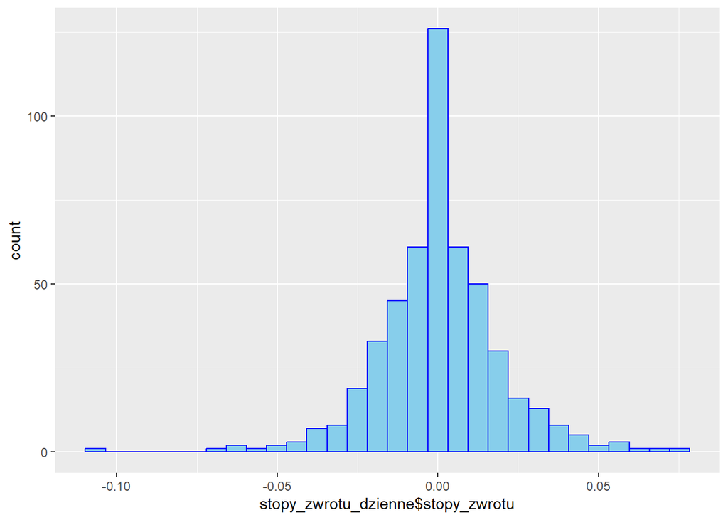

```r
ggplot()+
  geom_histogram(aes(x=stopy_zwrotu_dzienne$stopy_zwrotu), fill = "skyblue", color="blue")
```

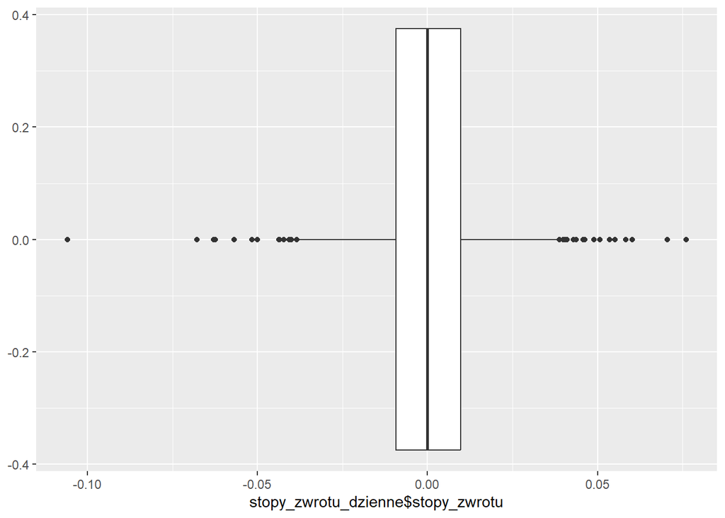

```r
ggplot()+
  geom_boxplot(aes(x=stopy_zwrotu_dzienne$stopy_zwrotu))
```

```r
dzienne<-stopy_zwrotu_dzienne$stopy_zwrotu
```

## Badanie zgodności 1. (rozkład normalny)

Naszym pierwszym zadaniem jest zbadanie zgodności rozkładu z rozkładem normalnym, przy pomocy testów: chi-kwadrat, Kołmogorowa i Shapiro-Wilka.

### Shapiro-Wilka

```r
shapiro.test(dzienne)
```

```
##
##  Shapiro-Wilk normality test
##
## data:  dzienne
## W = 0.95459, p-value = 2.812e-11
```

–> Odrzucamy h0.

### Kołmogorowa-smirnowa

```r
ks.test(dzienne,"pnorm", mean = mean(dzienne), sd = sd(dzienne))
```

```
##
##  Asymptotic one-sample Kolmogorov-Smirnov test
##
## data:  dzienne
## D = 0.075368, p-value = 0.006825
## alternative hypothesis: two-sided
```

–> Odrzucamy h0.

### Chi-kwadrat

Zaczniemy od odpowiedniej tabeli, podzieloną dzięki funkcji qnorm.

Mean oraz Sd estymujemy metodą największej wiarygodności.

Dane dzielimy na 20 klas.

Początkowo dostajemy:

```r
k<-numeric(0)
for (x in 0:20)
{
  x<-qnorm(x/20, mean = mean(dzienne), sd = sd(dzienne))
  k<-c(k,x)
}

df<-data.frame("dolna_gr"=k[1:20], "gorna_gr"=k[2:21])
head(df,5)
```

```
##      dolna_gr    gorna_gr
## 1        -Inf -0.03100415
## 2 -0.03100415 -0.02406577
## 3 -0.02406577 -0.01938448
## 4 -0.01938448 -0.01566394
## 5 -0.01566394 -0.01247205
```

Aktualizujemy tabelę o zliczone wartości:

```r
n<-numeric(0)
for(i in 1:20)
{
  n<-c(n,length(dzienne[dzienne>k[i] & dzienne<k[i+1]]))
}
df<-data.frame("dolna_gr"=k[1:20], "gorna_gr"=k[2:21], "n"= n[1:20])
print(df)
```

```
##         dolna_gr      gorna_gr  n
## 1           -Inf -0.0310041461 21
## 2  -0.0310041461 -0.0240657720 18
## 3  -0.0240657720 -0.0193844839 15
## 4  -0.0193844839 -0.0156639446 23
## 5  -0.0156639446 -0.0124720531 16
## 6  -0.0124720531 -0.0096056358 27
## 7  -0.0096056358 -0.0069494731 30
## 8  -0.0069494731 -0.0044290344 30
## 9  -0.0044290344 -0.0019904808 33
## 10 -0.0019904808  0.0004094104 67
## 11  0.0004094104  0.0028093017 26
## 12  0.0028093017  0.0052478553 29
## 13  0.0052478553  0.0077682940 25
## 14  0.0077682940  0.0104244567 22
## 15  0.0104244567  0.0132908739 26
## 16  0.0132908739  0.0164827654 17
## 17  0.0164827654  0.0202033048 18
## 18  0.0202033048  0.0248845929 13
## 19  0.0248845929  0.0318229670 18
## 20  0.0318229670           Inf 26
```

Zliczone wartości znajdują się w wektorze ‘n’. Wykonujemy test Chi-kwadrat.

```r
chisq.test(n, p = rep(0.05, 20))
```

```
##
##  Chi-squared test for given probabilities
##
## data:  n
## X-squared = 98.64, df = 19, p-value = 9.435e-13
```

–> Odrzucamy h0.

## Badanie zgodności 2. (rozkład t-Studenta)

Zaczniemy od estymacji stopni swobody. Korzystamy ze wzoru wariancja = stopnie swobody/ (stopnie swobody - 2 ). Zgodnie z zaleceniami przemnożymy dane przez 100.

```r
dzienne100 <- dzienne * 100
stop_sw <- function (x) {
wariancja <- sd(x) ^2
round ( 2*wariancja/ (wariancja-1) , 0 )
}

dfi<-stop_sw(dzienne100)
print(dfi)
```

```
## [1] 3
```

### Chi-kwadrat

Podobnie jak poprzednie buduję data.frame():

```r
k<-numeric(0)
for (x in 0:20)
{
  x<-qt(x/20, df=dfi)
  k<-c(k,x)
}

dane<-data.frame("dolna_gr"=k[1:20], "gorna_gr"=k[2:21])
head(dane,5)
```

```
##     dolna_gr   gorna_gr
## 1       -Inf -2.3533634
## 2 -2.3533634 -1.6377444
## 3 -1.6377444 -1.2497781
## 4 -1.2497781 -0.9784723
## 5 -0.9784723 -0.7648923
```

```r
n<-numeric(0)
for(i in 1:20)
{
  n<-c(n,length(dzienne100[dzienne100>k[i] & dzienne100<k[i+1]]))
}
dane<-data.frame("dolna_gr"=k[1:20], "gorna_gr"=k[2:21], "n"= n[1:20])
print(dane)
```

```
##      dolna_gr   gorna_gr  n
## 1        -Inf -2.3533634 40
## 2  -2.3533634 -1.6377444 28
## 3  -1.6377444 -1.2497781 25
## 4  -1.2497781 -0.9784723 25
## 5  -0.9784723 -0.7648923 20
## 6  -0.7648923 -0.5843897 18
## 7  -0.5843897 -0.4242016 24
## 8  -0.4242016 -0.2766707  9
## 9  -0.2766707 -0.1365982 24
## 10 -0.1365982  0.0000000  0
## 11  0.0000000  0.1365982  0
## 12  0.1365982  0.2766707 25
## 13  0.2766707  0.4242016  9
## 14  0.4242016  0.5843897 26
## 15  0.5843897  0.7648923 20
## 16  0.7648923  0.9784723 14
## 17  0.9784723  1.2497781 23
## 18  1.2497781  1.6377444 28
## 19  1.6377444  2.3533634 29
## 20  2.3533634        Inf 46
```

```r
chisq.test(n, p = rep(0.05, 20))
```

```
##
##  Chi-squared test for given probabilities
##
## data:  n
## X-squared = 113.84, df = 19, p-value = 1.558e-15
```

–> Odrzucamy h0.

### Kołmogorowa-smirnowa

```r
ks.test(dzienne100,"pt", df=dfi)
```

```
##
##  Asymptotic one-sample Kolmogorov-Smirnov test
##
## data:  dzienne100
## D = 0.074, p-value = 0.008372
## alternative hypothesis: two-sided
```

–> Odrzucamy h0.

## Dane tygodniowe

```r
srednia_tyg<-mean(stopy_zwrotu_tygodniowe$stopy_zwrotu_t)
odchyl_tyg<-sd(stopy_zwrotu_tygodniowe$stopy_zwrotu_t)
skosnosc_tyg<-skewness(stopy_zwrotu_tygodniowe$stopy_zwrotu_t)
kurtosis_tyg<-kurtosis(stopy_zwrotu_tygodniowe$stopy_zwrotu_t)
```

```r
srednie<-c(srednie,srednia_tyg)
odchylenia<-c(odchylenia, odchyl_tyg)
skosnosci<-c(skosnosci,skosnosc_tyg)
kurtozy<-c(kurtozy,kurtosis_tyg)
```

[output not shown]

[output not shown]

[output not shown]

[output not shown]

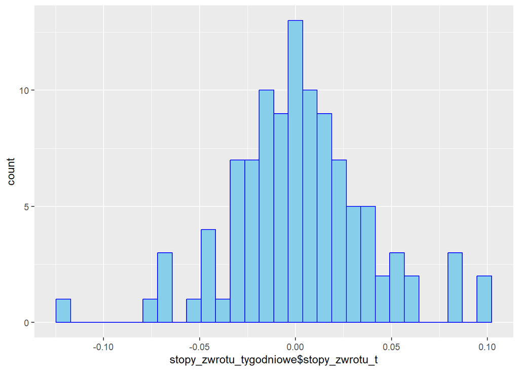

```r
ggplot()+
  geom_histogram(aes(x=stopy_zwrotu_tygodniowe$stopy_zwrotu_t), fill = "skyblue", color="blue")
```

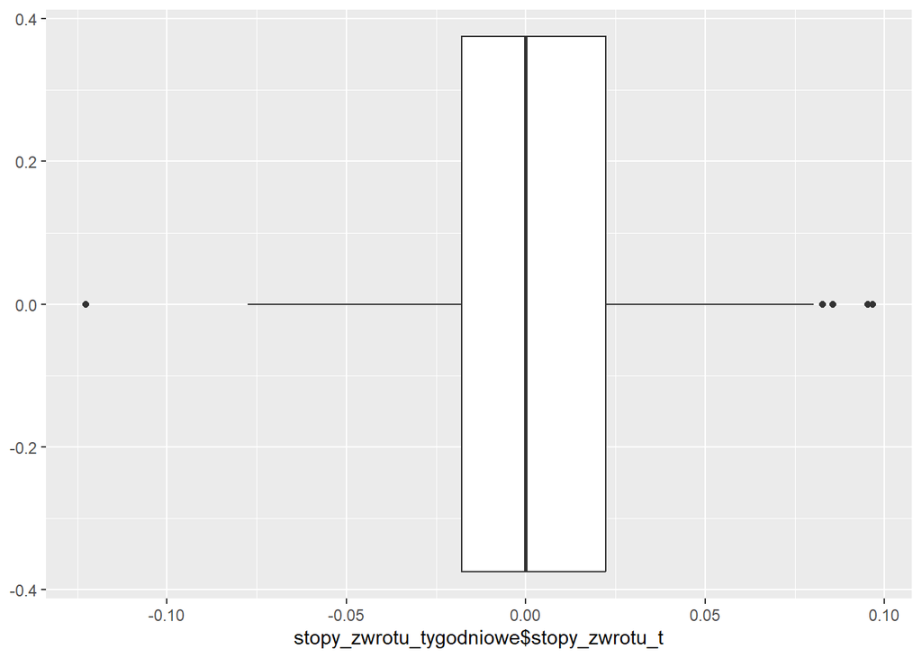

```r
ggplot()+
  geom_boxplot(aes(x=stopy_zwrotu_tygodniowe$stopy_zwrotu_t))
```

```r
tygodniowe<-stopy_zwrotu_tygodniowe$stopy_zwrotu_t
```

## Badanie zgodności 1. (rozkład normalny)

Naszym pierwszym zadaniem jest zbadanie zgodności rozkładu z rozkładem normalnym, przy pomocy testów: chi-kwadrat, Kołmogorowa i Shapiro-Wilka.

### Shapiro-Wilka

```r
shapiro.test(tygodniowe)
```

```
##
##  Shapiro-Wilk normality test
##
## data:  tygodniowe
## W = 0.97542, p-value = 0.04795
```

–> Odrzucamy h0 (wartość jednak jest bliska 0.05).

### Kołmogorowa-smirnowa

```r
ks.test(tygodniowe,"pnorm", mean = mean(tygodniowe), sd = sd(tygodniowe))
```

```
##
##  Asymptotic one-sample Kolmogorov-Smirnov test
##
## data:  tygodniowe
## D = 0.070579, p-value = 0.6723
## alternative hypothesis: two-sided
```

–> Przyjmujemy h0, rozkład zgodny z rozkładem normalnym.

### Chi-kwadrat

Mean oraz Sd estymujemy metodą największej wiarygodności.

Dane dzielimy na 10 klas.

Początkowo dostajemy:

```r
k<-numeric(0)
for (x in 0:10)
{
  x<-qnorm(x/10, mean = mean(tygodniowe), sd = sd(tygodniowe))
  k<-c(k,x)
}

df<-data.frame("dolna_gr"=k[1:10], "gorna_gr"=k[2:11])
head(df,5)
```

```
##       dolna_gr     gorna_gr
## 1         -Inf -0.043639730
## 2 -0.043639730 -0.027809877
## 3 -0.027809877 -0.016395439
## 4 -0.016395439 -0.006642223
## 5 -0.006642223  0.002473874
```

Aktualizujemy tabelę o zliczone wartości:

```r
n<-numeric(0)
for(i in 1:10)
{
  n<-c(n,length(tygodniowe[tygodniowe>k[i] & tygodniowe<k[i+1]]))
}
df<-data.frame("dolna_gr"=k[1:10], "gorna_gr"=k[2:11], "n"= n[1:10])
print(df)
```

```
##        dolna_gr     gorna_gr  n
## 1          -Inf -0.043639730  9
## 2  -0.043639730 -0.027809877  5
## 3  -0.027809877 -0.016395439 13
## 4  -0.016395439 -0.006642223 15
## 5  -0.006642223  0.002473874 14
## 6   0.002473874  0.011589971 11
## 7   0.011589971  0.021343187 10
## 8   0.021343187  0.032757625 10
## 9   0.032757625  0.048587479  8
## 10  0.048587479          Inf 10
```

Zliczone wartości znajdują się w wektorze ‘n’. Wykonujemy test Chi-kwadrat.

```r
chisq.test(n, p = rep(0.1, 10))
```

```
##
##  Chi-squared test for given probabilities
##
## data:  n
## X-squared = 7.4762, df = 9, p-value = 0.5877
```

–> Przyjmujemy hipotezę h0.

## Badanie zgodności 2. (rozkład t-Studenta)

Estymujemy liczbę stopni swobody:

```r
tygodniowe100 <- tygodniowe * 100
stop_sw <- function (x) {
wariancja <- sd(x) ^2
round ( 2*wariancja/ (wariancja-1) , 0 )
}

dfi<-stop_sw(tygodniowe100)
print(dfi)
```

```
## [1] 2
```

### Chi-kwadrat

```r
k<-numeric(0)
for (x in 0:10)
{
  x<-qt(x/10, df=dfi)
  k<-c(k,x)
}

dane<-data.frame("dolna_gr"=k[1:10], "gorna_gr"=k[2:11])
head(dane,5)
```

```
##     dolna_gr   gorna_gr
## 1       -Inf -1.8856181
## 2 -1.8856181 -1.0606602
## 3 -1.0606602 -0.6172134
## 4 -0.6172134 -0.2886751
## 5 -0.2886751  0.0000000
```

```r
n<-numeric(0)
for(i in 1:10)
{
  n<-c(n,length(tygodniowe100[tygodniowe100>k[i] & tygodniowe100<k[i+1]]))
}
dane<-data.frame("dolna_gr"=k[1:10], "gorna_gr"=k[2:11], "n"= n[1:10])
print(dane)
```

```
##      dolna_gr   gorna_gr  n
## 1        -Inf -1.8856181 25
## 2  -1.8856181 -1.0606602 10
## 3  -1.0606602 -0.6172134  7
## 4  -0.6172134 -0.2886751  2
## 5  -0.2886751  0.0000000  5
## 6   0.0000000  0.2886751  4
## 7   0.2886751  0.6172134  4
## 8   0.6172134  1.0606602  6
## 9   1.0606602  1.8856181  9
## 10  1.8856181        Inf 29
```

```r
chisq.test(n, p = rep(0.1, 10))
```

```
##
##  Chi-squared test for given probabilities
##
## data:  n
## X-squared = 76.525, df = 9, p-value = 7.896e-13
```

–> Odrzucamy hipotezę h0.

### Kołmogorowa-smirnowa

```r
ks.test(tygodniowe100,"pt", df=dfi)
```

```
##
##  Asymptotic one-sample Kolmogorov-Smirnov test
##
## data:  tygodniowe100
## D = 0.189, p-value = 0.001104
## alternative hypothesis: two-sided
```

–> Odrzucamy hipotezę h0.

*Zestawmy ze sobą wszystkie dane oraz p.value testów:*

```r
print(zestawione_dane)
```

```
##                 srednie   odch_std   skosnosci  kurtozy kolsmir_norm
## dzienne    0.0004094104 0.01909809 -0.16886116 6.368266  0.006825308
## tygodniowe 0.0024738743 0.03598264 -0.03044924 4.299661  0.672319984
##                chi_norm      shapiro kolsmir_tstud    chi_tstud
## dzienne    9.434929e-13 2.812247e-11    0.00837208 1.558017e-15
## tygodniowe 5.876677e-01 4.794710e-02    0.00110443 7.895824e-13
```

# W2. Asseco Business Solutions SA (ABS) (1/3 danych)

Jako, że obliczenia będą analogiczne, pominiemy podobne obliczenia, pokażemy tylko różnice w testach Chi-kwadrat.

Danych dziennych mamy 166, zatem podzielimy dane na 12 klas.

```
## [1] "Chi, rozk. norm:"
```

```
##         dolna_gr      gorna_gr  n
## 1           -Inf -0.0261963060 11
## 2  -0.0261963060 -0.0182722367 11
## 3  -0.0182722367 -0.0126866610 10
## 4  -0.0126866610 -0.0080386387 14
## 5  -0.0080386387 -0.0038380154 17
## 6  -0.0038380154  0.0001743987 32
## 7   0.0001743987  0.0041868127 13
## 8   0.0041868127  0.0083874360 15
## 9   0.0083874360  0.0130354584 11
## 10  0.0130354584  0.0186210341  7
## 11  0.0186210341  0.0265451034 12
## 12  0.0265451034           Inf 13
```

```
## [1] "Chi, rozk. t-studenta:"
```

```
##      dolna_gr   gorna_gr  n
## 1        -Inf -1.8179182 22
## 2  -1.8179182 -1.1504756 16
## 3  -1.1504756 -0.7648923 10
## 4  -0.7648923 -0.4758804 12
## 5  -0.4758804 -0.2293647 15
## 6  -0.2293647  0.0000000  1
## 7   0.0000000  0.2293647  1
## 8   0.2293647  0.4758804 13
## 9   0.4758804  0.7648923 14
## 10  0.7648923  1.1504756  5
## 11  1.1504756  1.8179182 12
## 12  1.8179182        Inf 26
```

Danych tygodniowych mamy 35, więc do testów chi-kwadrat dzielimy je na 6 klas.

```
## [1] "Chi, rozk. norm:"
```

```
##      dolna_gr    gorna_gr n
## 1        -Inf -0.02495787 5
## 2 -0.02495787 -0.00743366 6
## 3 -0.00743366  0.00663050 6
## 4  0.00663050  0.02069466 7
## 5  0.02069466  0.03821887 8
## 6  0.03821887         Inf 3
```

```
## [1] "Chi, rozk. t-studenta:"
```

```
##    dolna_gr  gorna_gr  n
## 1      -Inf -1.264911  8
## 2 -1.264911 -0.500000  4
## 3 -0.500000  0.000000  3
## 4  0.000000  0.500000  1
## 5  0.500000  1.264911  4
## 6  1.264911       Inf 14
```

Ostatecznie dostajemy takie wyniki:

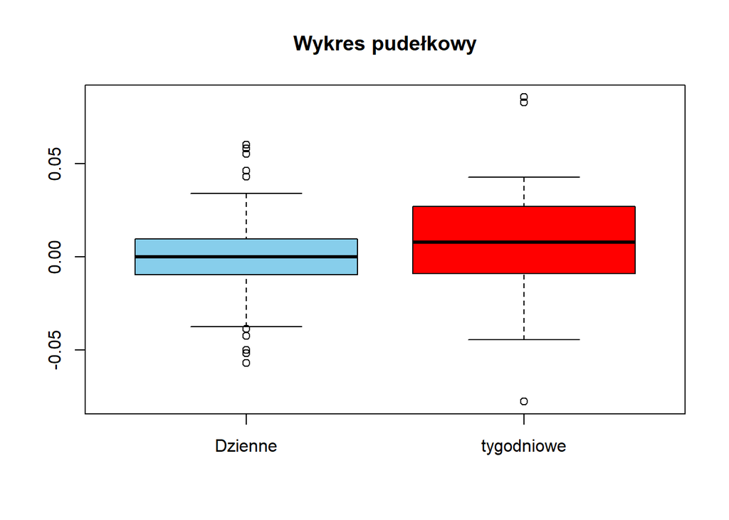

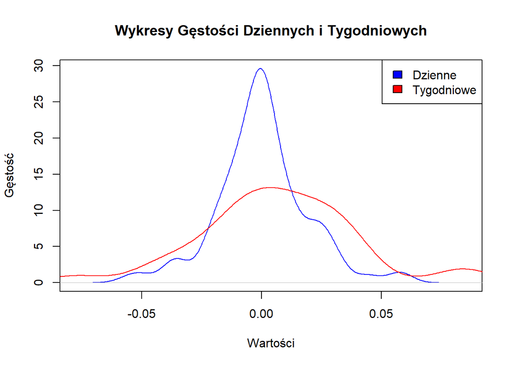

```
##                 srednie   odch_std  skosnosci  kurtozy kolsmir_norm   chi_norm
## dzienne    0.0001743987 0.01906784 0.15039891 4.313613    0.1340033 0.00102198
## tygodniowe 0.0066305003 0.03265212 0.08378835 3.868657    0.9489445 0.77002732
##                shapiro kolsmir_tstud    chi_tstud
## dzienne    0.001598607     0.2544762 4.815660e-07
## tygodniowe 0.481997998     0.0149535 1.694101e-03
```

### **Wyniki**

*Dla rozkładu dziennego widzimy zgodności z oboma testami Kołmogorova-Smirnowa.* *Dla rozkładu tygodniowego jednogłośna zgodność z rozkładem normalnym, przeciwnie w przypadku rozkładu t-Studenta.*

# W1. AmRest Holdings SE (EAT) (mWIG20)

```
## [1] "Chi, rozk. norm:"
```

```
##         dolna_gr      gorna_gr  n
## 1           -Inf -4.029462e-02 22
## 2  -4.029462e-02 -3.141416e-02 21
## 3  -3.141416e-02 -2.542255e-02 22
## 4  -2.542255e-02 -2.066062e-02 22
## 5  -2.066062e-02 -1.657530e-02 24
## 6  -1.657530e-02 -1.290656e-02 31
## 7  -1.290656e-02 -9.506921e-03 21
## 8  -9.506921e-03 -6.280999e-03 29
## 9  -6.280999e-03 -3.159882e-03 32
## 10 -3.159882e-03 -8.824961e-05 19
## 11 -8.824961e-05  2.983383e-03 47
## 12  2.983383e-03  6.104500e-03 25
## 13  6.104500e-03  9.330422e-03 29
## 14  9.330422e-03  1.273006e-02 30
## 15  1.273006e-02  1.639880e-02 15
## 16  1.639880e-02  2.048412e-02 22
## 17  2.048412e-02  2.524605e-02 26
## 18  2.524605e-02  3.123766e-02 22
## 19  3.123766e-02  4.011812e-02 15
## 20  4.011812e-02           Inf 26
```

```
## [1] "Chi, rozk. t-studenta:"
```

```
##      dolna_gr   gorna_gr  n
## 1        -Inf -2.9199856 51
## 2  -2.9199856 -1.8856181 49
## 3  -1.8856181 -1.3862066 33
## 4  -1.3862066 -1.0606602 23
## 5  -1.0606602 -0.8164966 20
## 6  -0.8164966 -0.6172134 16
## 7  -0.6172134 -0.4447496 18
## 8  -0.4447496 -0.2886751 15
## 9  -0.2886751 -0.1421338 13
## 10 -0.1421338  0.0000000  5
## 11  0.0000000  0.1421338  5
## 12  0.1421338  0.2886751 16
## 13  0.2886751  0.4447496 19
## 14  0.4447496  0.6172134  7
## 15  0.6172134  0.8164966 17
## 16  0.8164966  1.0606602 22
## 17  1.0606602  1.3862066 23
## 18  1.3862066  1.8856181 25
## 19  1.8856181  2.9199856 51
## 20  2.9199856        Inf 46
```

Tygodniowe:

```
## [1] "Chi, rozk. norm:"
```

```
##         dolna_gr      gorna_gr  n
## 1           -Inf -0.0617194656  7
## 2  -0.0617194656 -0.0407418661 10
## 3  -0.0407418661 -0.0256155410 11
## 4  -0.0256155410 -0.0126906539 14
## 5  -0.0126906539 -0.0006100727 10
## 6  -0.0006100727  0.0114705084 10
## 7   0.0114705084  0.0243953955 17
## 8   0.0243953955  0.0395217206 12
## 9   0.0395217206  0.0604993201  6
## 10  0.0604993201           Inf  8
```

```
## [1] "Chi, rozk. t-studenta:"
```

```
##      dolna_gr   gorna_gr  n
## 1        -Inf -1.8856181 34
## 2  -1.8856181 -1.0606602 10
## 3  -1.0606602 -0.6172134  3
## 4  -0.6172134 -0.2886751  4
## 5  -0.2886751  0.0000000  1
## 6   0.0000000  0.2886751  3
## 7   0.2886751  0.6172134  4
## 8   0.6172134  1.0606602  3
## 9   1.0606602  1.8856181 11
## 10  1.8856181        Inf 32
```

Ostatecznie dostajemy takie wyniki:

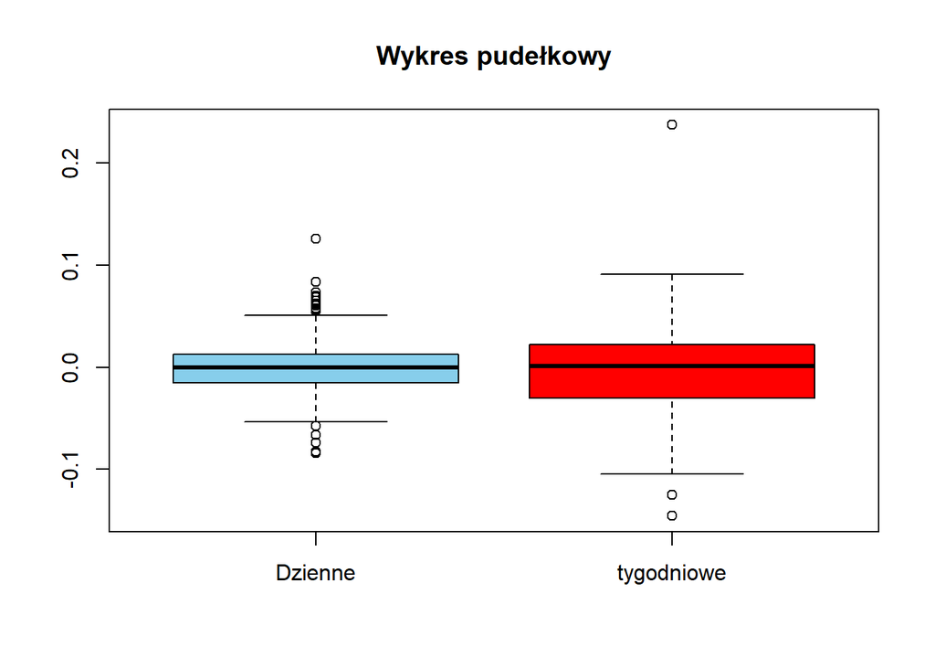

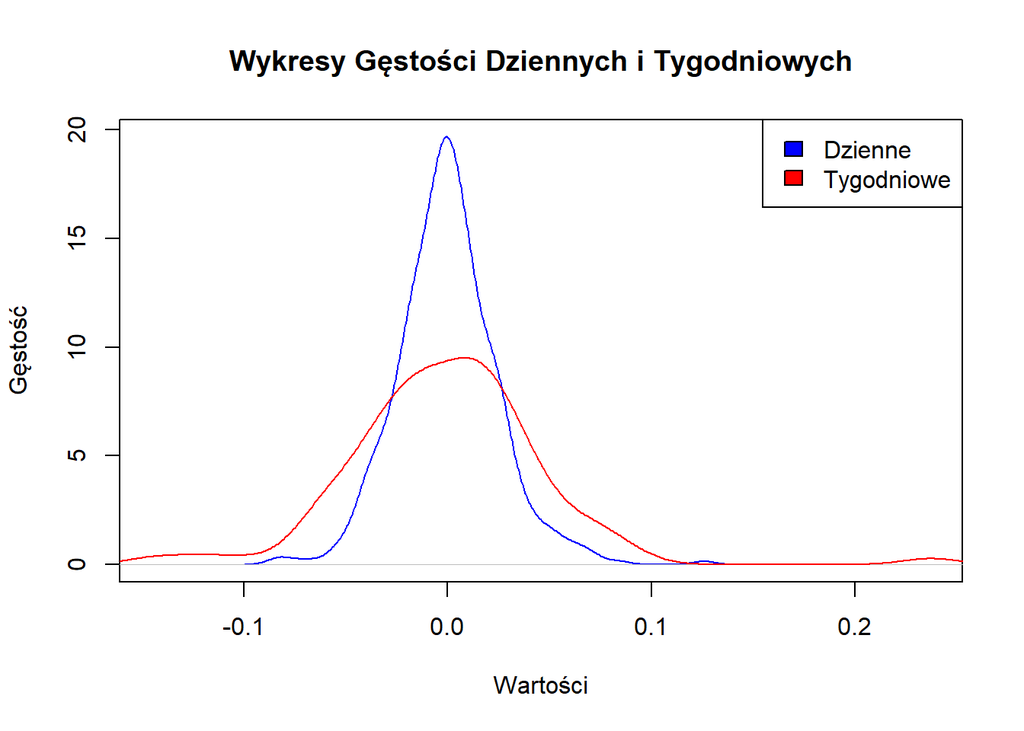

```
##                  srednie   odch_std skosnosci  kurtozy kolsmir_norm    chi_norm
## dzienne    -8.824961e-05 0.02444374 0.3470822 4.914467    0.1439502 0.006516296
## tygodniowe -6.100727e-04 0.04768391 0.7688011 8.362285    0.6956018 0.419880737
##                 shapiro kolsmir_tstud    chi_tstud
## dzienne    4.208684e-06  4.491533e-07 5.006661e-27
## tygodniowe 3.045177e-05  6.964026e-06 1.589806e-23
```

### **Wyniki**

Zgodność z rozkładem normalnym dla danych dziennych wskazuje tylko test Kołmogorova Smirnova. Żaden jeśli chodzi o zgodność z rozkładem t-Studenta. W przypadku danych tygodniowych, widzimy zgodność z rozkładem normalnym dla testów Chi-kwadrat oraz Kołmogorova-Smirnowa.

# W2. AmRest Holdings SE (EAT)

Dzienne:

```
## [1] "Chi, rozk. norm:"
```

```
##         dolna_gr      gorna_gr  n
## 1           -Inf -0.0312642482 14
## 2  -0.0312642482 -0.0220296027 10
## 3  -0.0220296027 -0.0155202185 12
## 4  -0.0155202185 -0.0101034513 12
## 5  -0.0101034513 -0.0052080792 13
## 6  -0.0052080792 -0.0005320447 13
## 7  -0.0005320447  0.0041439897 29
## 8   0.0041439897  0.0090393618 11
## 9   0.0090393618  0.0144561290 16
## 10  0.0144561290  0.0209655132 11
## 11  0.0209655132  0.0302001587 15
## 12  0.0302001587           Inf 10
```

```
## [1] "Chi, rozk. t-studenta:"
```

```
##      dolna_gr   gorna_gr  n
## 1        -Inf -1.8179182 33
## 2  -1.8179182 -1.1504756 12
## 3  -1.1504756 -0.7648923  9
## 4  -0.7648923 -0.4758804  9
## 5  -0.4758804 -0.2293647  6
## 6  -0.2293647  0.0000000  5
## 7   0.0000000  0.2293647  8
## 8   0.2293647  0.4758804  8
## 9   0.4758804  0.7648923  6
## 10  0.7648923  1.1504756 14
## 11  1.1504756  1.8179182 13
## 12  1.8179182        Inf 30
```

Tygodniowe:

```
## [1] "Chi, rozk. norm:"
```

```
##       dolna_gr     gorna_gr n
## 1         -Inf -0.031174775 5
## 2 -0.031174775 -0.010811134 8
## 3 -0.010811134  0.005531832 6
## 4  0.005531832  0.021874798 5
## 5  0.021874798  0.042238440 6
## 6  0.042238440          Inf 5
```

```
## [1] "Chi, rozk. t-studenta:"
```

```
##    dolna_gr  gorna_gr  n
## 1      -Inf -1.264911 13
## 2 -1.264911 -0.500000  1
## 3 -0.500000  0.000000  1
## 4  0.000000  0.500000  3
## 5  0.500000  1.264911  3
## 6  1.264911       Inf 14
```

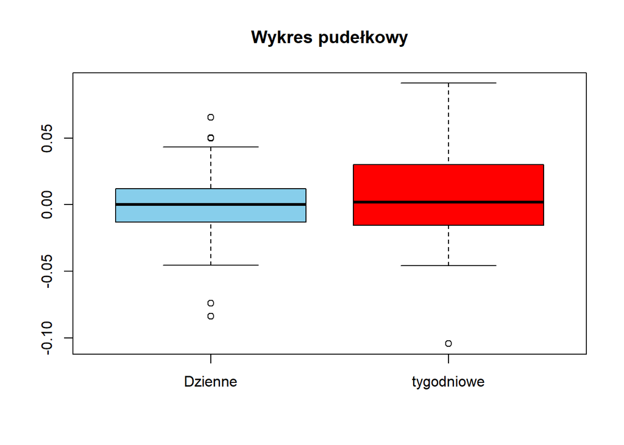

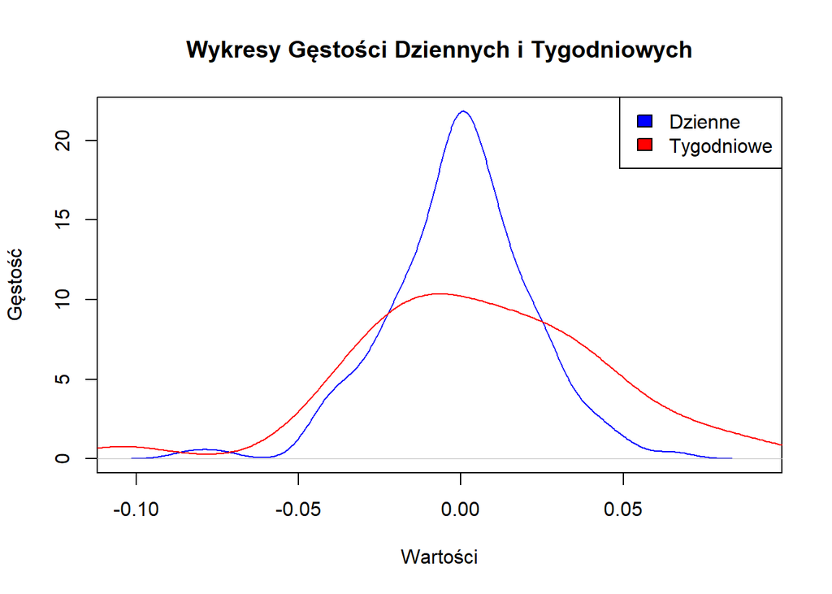

```
##                  srednie   odch_std  skosnosci  kurtozy kolsmir_norm   chi_norm
## dzienne    -0.0005320447 0.02222150 -0.3331282 4.252294    0.4226688 0.03400057
## tygodniowe  0.0055318324 0.03794272 -0.2101412 3.789987    0.9853561 0.94758886
##               shapiro kolsmir_tstud    chi_tstud
## dzienne    0.04050969    0.01580878 2.901250e-11
## tygodniowe 0.68727546    0.00634606 9.367249e-06
```

### **Wyniki**

*Dla danych dziennych, widzimy zgodność z rozkładem normalnym tylko w przypadku Kołmogorova Smirnowa.* *Dla danych tygodniowych, widzimy zgodność z rozkładem normalnym w przypadku każdego testu.*